# A3: SPL Library Checkouts

### Introduction

The data I am analyzing is the books checked out more than ten times from 2017-2023. One thing I want to find out is which medium or UsageClass is more popular and if the ratio changes from year to year. I would also like to do something similar for the MaterialType of the publication like ebook, magazine, movie, music, etc. The last thing I would like to analyze is what books are the most popular and how much does that list change from year to year.

### Summary Information

There are 8999132 digital checkouts within our dataset and 10166737 physical checkouts in the dataset which split the 19165869 total checkouts evenly. Also I found that there are 32 types of publications like Ebooks, Magazines, Books, videos, etc. Another interesting piece of my data that I found is that the most viewed book overall is Educated : a memoir / Tara Westover.

### The Dataset

- Who collected/published the data?  
  The data was collected by the Seattle Public Library
- What are the parameters of the data (dates, number of checkouts, kinds of books, etc.)? The dataset I used ranges from 2017-2023, although, the information for 2023 is limited because it has just begun. The “Checkouts” column in the dataset is referencing the amount of checkouts in that given month, and there are many types of publications from books, magazines, ebooks, etc.
- How was the data collected or generated? The data has been generated from 2017 to current day everytime a person would checkout a publication. The entire database goes back to 2005, however, which was possible because an artist/ professor kept the data for an exhibit in the library.
- Why was the data collected?  
  The data was officially collected in 2017 due to bill passed by Barack Obama.
- What, if any, ethical questions do you need to consider when working with this data? I think something to consider is how the patrons’ of library identities were kept private. Also one should consider the events that were happening during the years the collection was happening and try to reference events to certain trends i.e. the Pandemic or the BLM movement.
- What are possible limitations or problems with this data? (at least 200 words) Possibly the biggest limitation is that titles are not consistent across mediums. At first, I wanted to create a chart exploring the most checked out titles across all mediums, but it would not be possible with my knowledge. I would’ve had to do some serious string manipulation to make a title from one medium match a title in another medium, and it just didn’t seem intuitive. Another limitation I found is that the data is only based on monthly checkouts rather than yearly checkouts. This is good if you want to know monthly trends, but can be annoying when you are trying to find out yearly trends. In order to remedy this problem, a person would have to do some data manipulation as I did in chart-3, and I’m still not even sure if what I did is exactly correct. Another possible limitation from the data is that everything prior to 2017 is based on an art project from one of the Professors as the library. He wanted to create a visualization regarding the checkout data from 2005 -2017, but I wonder how he collected the data and noone else did. It seems like an interesting project, and the data is likely correct, but this information should still be considered when addressing the dataset as a whole.

### First Trends Over Time Chart

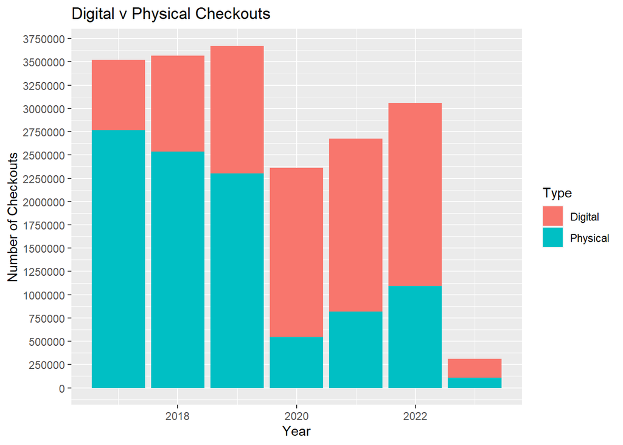

This chart shows the total number of checkouts per year based on whether the checkout was digital or physical. I think it is kind of interesting because the trend does shift quite drastically and at first I didn’t understand why. After some thought, I realized the years when digital overtook Physical were the same years that the Pandemic was at its peak. 2023 has only just begun, but you can still see that the trend from the Pandemic has continued and there are still more Digital checkouts than Physical.

### Second Trends Over Time Chart

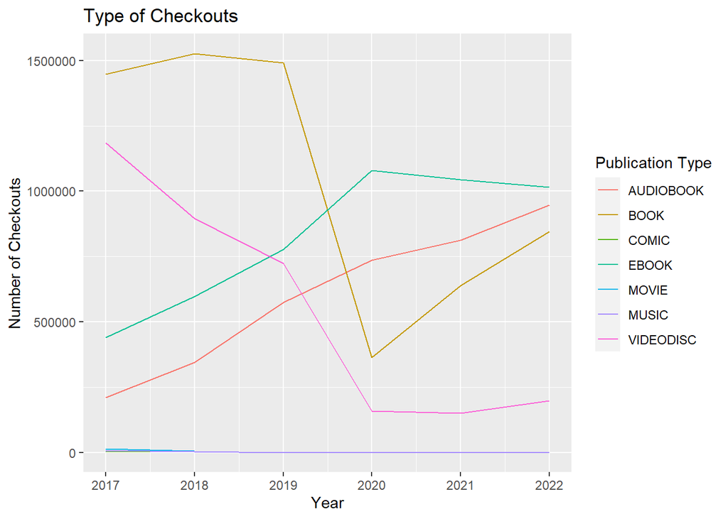

### Your Choice

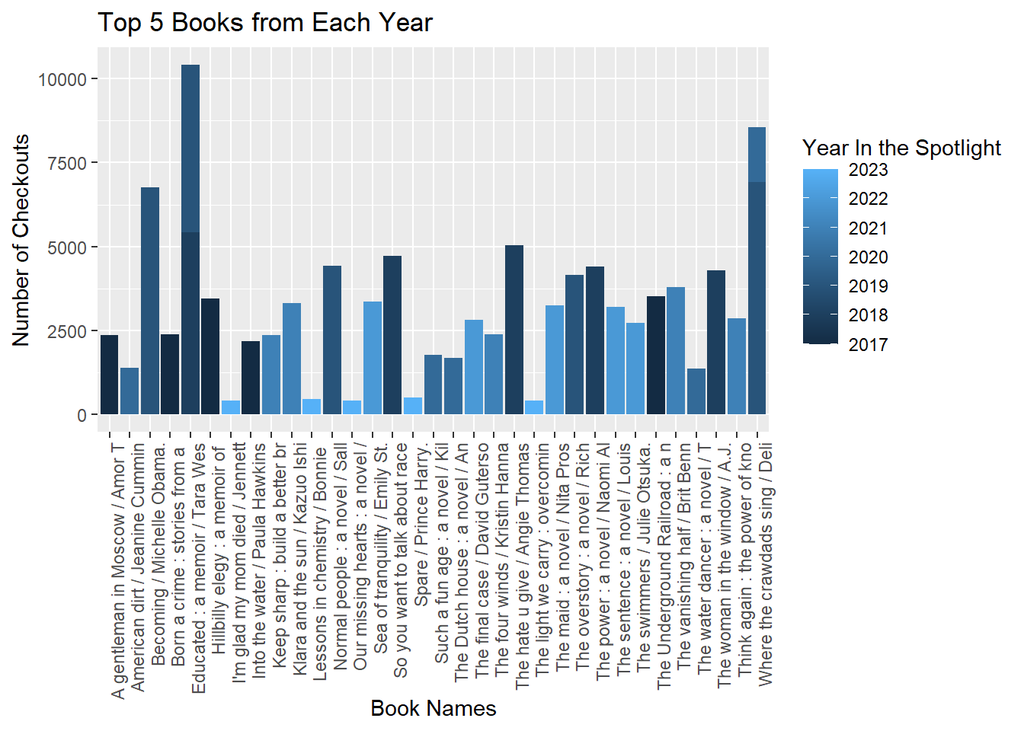

The Top 5 Books from Each Year chart shows only publications of the type “BOOK” as found in the original dataset. I was curious to find which books recieved the most attention from year to year. The chart shows that the most popular book was a memoir, which suprised me a bit, but makes me curious about the content.